# Data Analytics and Visualization

Analytics :

1. Which is the most common breed to be tweeted about? Insight : Golden Retriever, a clear winner, outperforming the Labrador Retrieverby a factor of 50 tweets
2. Which breed is favorited and retweeted the most? Insight : Owing to the number of tweets on the subject, the Golden Retriever again wins. Order of favorite and retweeting matches the count of tweets. However, when the mean of the ratings are taken, random objects appear at the top of the list. These seem to be especially peculiar images having a high number of favorites.
3. Which breed has got the highest ratings? Insight : Golder Retriever leads the charge again. But is defeated by a non-dog element, the 'bowtie'! However, this is because of an outlier which was predicted as bowtie, having a rating of 1776
4. Which are the breeds commonly associated with floofer? Insight : Samoyed,wire-haired_fox_terrier,golden_retriever,chow,Pomeranian,Lhasa,English_springer are the floofiest dogs out there.
5. What is the most common source for the tweets? Insight : Twitter for IPhone, followed by WebClient (browser)
6. Apart from twitter, which is the most popular platform endorsed along the tweets? Insight : gofundme with 22 records

Visualization :

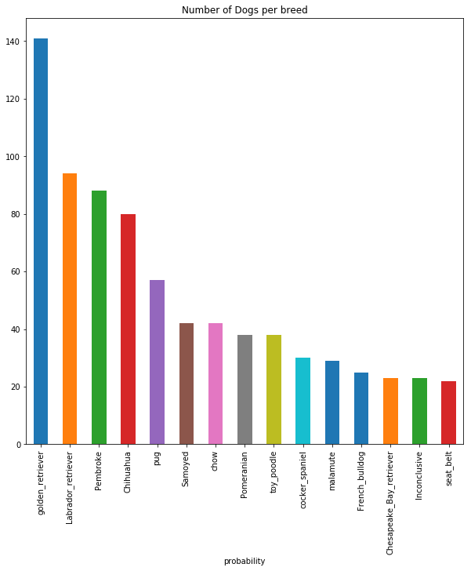

Golden Retriever ki Jai.